# Regressions

Alejandra Garcia Isaza

2022-07-12

Diss Research questions:

1. Can both structural and relational components of family-school connections be identified using exploratory factor analysis approaches in the Conexiones parents’ assessment data? –> addressed with Exploratory Factor Analyses, not included here.

   I identified *15 predictors* in the EFA part of my study. They are different parent engagement practices, some are considered structural and some are considered relational (“hwi_1” “hwi_2” “hwi_3” “monit” “str_home” “convos_1” “convos_2” “convos_3” “sbi_1” “sbi_2” “belong” “endorse” “value_ed” “rel_1” “rel_2” )

   The *outcome* is youth engagement (called “engage”)

   The *covariates* are parent’s educational level (q36_hv1) and parent’s comfort with ENG (q173_3_p1)
2. What specific structural and relational components of family-school connections in the Conexiones parents’ assessment data are significantly and positively associated with positive students’ school engagement? –> to be addressed with simple linear regression models
3. What model best predicts positive students’ school engagement, a structural components only model or a combined structural plus relational components model? –> to be addressed with a step-wise multiple linear regression model, with predictor blocks

   demo vars: if effects hold when demo vars included…

   model 1a: what is the univar association of each predictor with the outcome (15 models) model 1b: what is the multivar assicition of each predictor with th outcome adjusting for demo charcs (covariates) (15 models)

   model 2a: what is the multivar effect of the structural predictors with th outcome (1 model, 10 composire scores simultaneously) model 2b: what is the multivar effect of the structural predictors with th outcome adjusting for demo charcr (1 model, 10 composite scores simultaneously + demo vars: block 1 demos, block 2: structural (10 scores))

   model 3a: what is the multivar effect of the relational predictors with th outcome (1 model, 5 composite scores simultaneously) model 3b: what is the multivar effect of the relational predictors with th outcome adjusting for demo charcr (1 model, 5 composite scores simultaneously + demo vars: block 1 demos, block 2: relational (5 scores))

   model 4a: what is the multivar effect of structural and relational predictors on the outcome (1 model, 15 scores simultaneosuly) model 4b: what is the multivar effect of structural and relational predictors on the outcome adjusting for demo charcr (1 model, 15 scores simultaneosuly + demo vars: block 1 demos, block 2: structural + block 3: relational; if RQ changes and is that interest is above and beyond structural)

   moderation

   Ed. level: look at distruibution and dichotomize hoe it makes more sense: option could be HS, Bachelor, higher lang comf: look at distruibution and dichotomize hoe it makes more sense.

   this is exploratory: use the benjamini correction: test the effects of moderation on model 1a (if covariates don’t matter) or 1b (if covariates do matter) = 30 models (say in analysis plan the test of moderation are exploratory and adjustment to p value will be done)

Elementary or less 23.4 Middle school 17 + Some HS 20.2 = 37.2 (reference) Complete HS or GED 32.2 Post secondary ed 7.4

# Loading the dataset (only analysis vars)

```r
d <- read_sav(here("data", "d4 - scales & covariates.sav"))

d <- d %>%
  mutate(parent_role = factor(parent_role),
         parent_role = relevel(parent_role, ref = "1"), # mom
         parent_ed = factor(parent_ed),
         parent_ed = case_when(
           parent_ed == "1" | parent_ed == "2" | parent_ed == "3" ~ "1", #elementary or less
           parent_ed == "4" | parent_ed == "5" ~ "2", #incomplete HS
           parent_ed == "6" | parent_ed == "7" ~ "3", #secondary
           parent_ed == "8" | parent_ed == "9" | parent_ed == "10" ~ "4"), #post-secondary
         parent_ed = factor(parent_ed),
         parent_ed = relevel(parent_ed, ref = "2"),
         parent_eng_comf = as.numeric(parent_eng_comf), # average comfort
         youth_gender = factor(youth_gender),
         youth_gender = relevel(youth_gender, ref = "1"), # male
         youth_grlevel = factor(youth_grlevel),
         youth_grlevel = relevel(youth_grlevel, ref = "2")) # 7th grade
```

# descriptive stats function

```r
only_scales <- d %>%
  select(108:123, -hwi_3, -monit)

descrip_table <- descriptives(only_scales) %>%
  rename(c("Scale" = "column"))
```

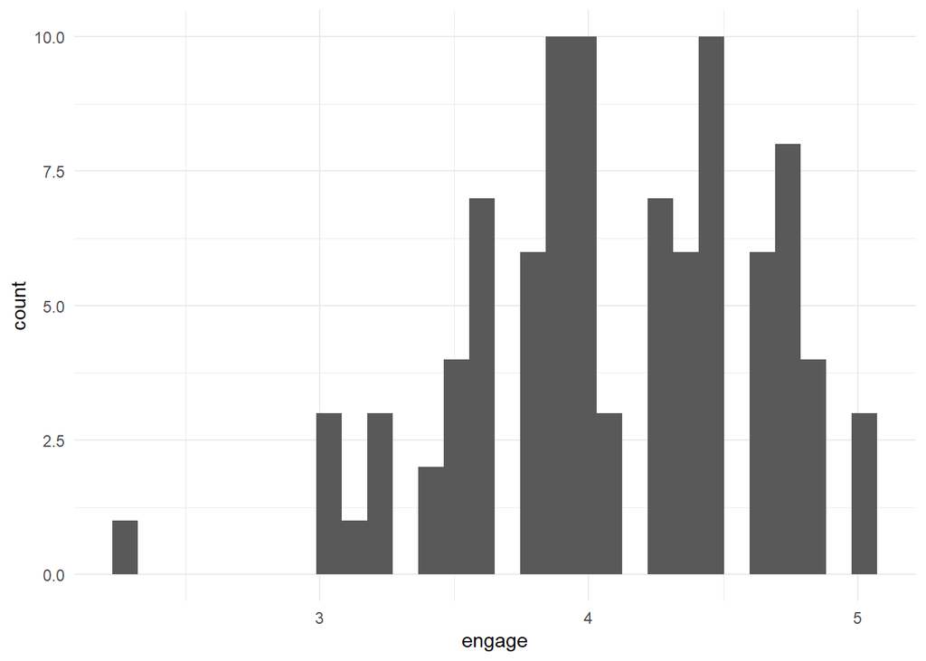

```r
ggplot(d, aes(engage)) +
  geom_histogram() # approxiamtes normality, shows one outlier z-score greater than 3.0 or -3.0 (converting to Z-scores)
```

```r
# extreme outlier were removed from analysis and result did not meaningfully changed.

d$engage
```

```
##  [1] 4.500 4.250 4.375 3.875 4.875 3.875 3.625 4.000 4.750 4.375 3.250 4.375
## [13] 3.875 3.625 3.500 3.875 3.875 3.625 3.750 3.750 4.375 4.500 4.500 3.875
## [25] 4.875 4.250 4.875 3.875 4.625 4.625 4.000 3.250 5.000 4.000 4.000 4.125
## [37] 4.125 4.500 4.000 4.500 3.500 5.000 3.625 3.875 3.875 4.250 3.625 4.750
## [49] 4.750 3.000 4.625 4.250 3.625 4.750 5.000 3.750 4.750 4.250 4.000 4.750
## [61] 4.250 3.375 4.875 3.750 4.500 4.625 4.000 3.875 3.625 4.750 4.250 4.625
## [73] 3.125 4.625 3.000 4.375 4.000 4.375 3.500 3.000 2.250 4.500 4.000 3.750
## [85] 4.500 4.750 3.375 4.125 4.500 3.750 4.000 3.250 3.500 4.500
## attr(,"format.spss")
## [1] "F8.2"
```

# correlation matrix

```r
library(Hmisc)
rcorr(as.matrix(only_scales), type = "pearson")
```

```
##          hwi_1 hwi_2 str_home convos_1 convos_2 convos_3 sbi_1 sbi_2 belong
## hwi_1     1.00  0.33     0.48     0.30     0.33     0.18  0.33  0.50   0.29
## hwi_2     0.33  1.00     0.33     0.25     0.30     0.04  0.30  0.36   0.25
## str_home  0.48  0.33     1.00     0.40     0.44     0.36  0.67  0.53   0.42
## convos_1  0.30  0.25     0.40     1.00     0.47     0.51  0.30  0.18   0.17
## convos_2  0.33  0.30     0.44     0.47     1.00     0.47  0.44  0.41   0.19
## convos_3  0.18  0.04     0.36     0.51     0.47     1.00  0.33  0.17   0.25
## sbi_1     0.33  0.30     0.67     0.30     0.44     0.33  1.00  0.45   0.37
## sbi_2     0.50  0.36     0.53     0.18     0.41     0.17  0.45  1.00   0.24
## belong    0.29  0.25     0.42     0.17     0.19     0.25  0.37  0.24   1.00
## endorse   0.23  0.23     0.38     0.18     0.18     0.22  0.36  0.23   0.73
## value_ed  0.05 -0.02     0.30     0.31     0.15     0.33  0.19 -0.15   0.27
## rel_1     0.21  0.19     0.41     0.22     0.29     0.25  0.38  0.16   0.62
## rel_2     0.34  0.20     0.35     0.19     0.23     0.22  0.45  0.27   0.74
## engage    0.19  0.26     0.21    -0.02     0.19     0.12  0.21  0.22   0.00
##          endorse value_ed rel_1 rel_2 engage
## hwi_1       0.23     0.05  0.21  0.34   0.19
## hwi_2       0.23    -0.02  0.19  0.20   0.26
## str_home    0.38     0.30  0.41  0.35   0.21
## convos_1    0.18     0.31  0.22  0.19  -0.02
## convos_2    0.18     0.15  0.29  0.23   0.19
## convos_3    0.22     0.33  0.25  0.22   0.12
## sbi_1       0.36     0.19  0.38  0.45   0.21
## sbi_2       0.23    -0.15  0.16  0.27   0.22
## belong      0.73     0.27  0.62  0.74   0.00
## endorse     1.00     0.41  0.71  0.66  -0.07
## value_ed    0.41     1.00  0.45  0.34   0.03
## rel_1       0.71     0.45  1.00  0.54  -0.13
## rel_2       0.66     0.34  0.54  1.00   0.05
## engage     -0.07     0.03 -0.13  0.05   1.00
##
## n
##          hwi_1 hwi_2 str_home convos_1 convos_2 convos_3 sbi_1 sbi_2 belong
## hwi_1       93    93       93       93       93       93    93    93     93
## hwi_2       93    93       93       93       93       93    93    93     93
## str_home    93    93       94       94       94       94    94    94     94
## convos_1    93    93       94       94       94       94    94    94     94
## convos_2    93    93       94       94       94       94    94    94     94
## convos_3    93    93       94       94       94       94    94    94     94
## sbi_1       93    93       94       94       94       94    94    94     94
```

[output cut: 39 more lines]

```
##          endorse value_ed rel_1  rel_2  engage
## hwi_1    0.0240  0.6078   0.0403 0.0007 0.0751
## hwi_2    0.0243  0.8655   0.0697 0.0542 0.0119
## str_home 0.0002  0.0035   0.0000 0.0005 0.0429
## convos_1 0.0867  0.0025   0.0362 0.0643 0.8566
## convos_2 0.0882  0.1572   0.0044 0.0256 0.0705
## convos_3 0.0332  0.0010   0.0162 0.0295 0.2655
## sbi_1    0.0004  0.0702   0.0002 0.0000 0.0454
## sbi_2    0.0247  0.1478   0.1178 0.0086 0.0313
## belong   0.0000  0.0074   0.0000 0.0000 0.9704
## endorse          0.0000   0.0000 0.0000 0.5322
## value_ed 0.0000           0.0000 0.0008 0.7746
## rel_1    0.0000  0.0000          0.0000 0.1948
## rel_2    0.0000  0.0008   0.0000        0.6584
## engage   0.5322  0.7746   0.1948 0.6584
```

| # RESEARCH QUESTION 2 |
| --- |

```
 model 1a: what is the univar association of each predictor with the outcome (15 models)
 model 1b: what is the multivar assiciation of each predictor with th outcome adjusting for      demo charcs (covariates) (15 models)
```

# 2.1. Academic approach (tutor)

```r
m_hwi_1a <- lm(engage ~ hwi_1, d)
summary(m_hwi_1a) # p = 0.07
```

```
##
## Call:
## lm(formula = engage ~ hwi_1, data = d)
##
## Residuals:
##      Min       1Q   Median       3Q      Max
## -1.58925 -0.35489 -0.01286  0.46022  1.00884
##
## Coefficients:
##             Estimate Std. Error t value Pr(>|t|)
## (Intercept)  3.68733    0.23493  15.695   <2e-16 ***
## hwi_1        0.15192    0.08436   1.801   0.0751 .
## ---
## Signif. codes:  0 '***' 0.001 '**' 0.01 '*' 0.05 '.' 0.1 ' ' 1
##
## Residual standard error: 0.5417 on 91 degrees of freedom
##   (1 observation deleted due to missingness)
## Multiple R-squared:  0.03441,    Adjusted R-squared:  0.0238
## F-statistic: 3.243 on 1 and 91 DF,  p-value: 0.07505
```

```r
#arm::display(m_hwi_1a, detail = TRUE)

m_hwi_1b <- lm(engage ~ parent_role + parent_age + parent_ed + parent_eng_comf + youth_age + youth_gender + youth_grlevel + hwi_1, d)
summary(m_hwi_1b) # p = 0.04 (not completely sure if this is the p-value i should look at?)
```

```
##
## Call:
## lm(formula = engage ~ parent_role + parent_age + parent_ed +
##     parent_eng_comf + youth_age + youth_gender + youth_grlevel +
##     hwi_1, data = d)
##
## Residuals:
##      Min       1Q   Median       3Q      Max
## -1.34295 -0.39121 -0.02261  0.45141  0.97726
##
## Coefficients:
##                   Estimate Std. Error t value Pr(>|t|)
## (Intercept)      2.9345529  1.8630728   1.575   0.1197
## parent_role2     0.0319687  0.3610626   0.089   0.9297
## parent_age       0.0002277  0.0125764   0.018   0.9856
## parent_ed1       0.0366005  0.1704145   0.215   0.8306
## parent_ed3       0.0335568  0.1558114   0.215   0.8301
## parent_ed4       0.1673013  0.2966671   0.564   0.5746
## parent_eng_comf -0.0586942  0.0506502  -1.159   0.2505
## youth_age        0.0414691  0.1460060   0.284   0.7772
## youth_gender2    0.2492974  0.1301576   1.915   0.0595 .
## youth_grlevel1   0.1619321  0.2068826   0.783   0.4364
## youth_grlevel3   0.2292739  0.2046429   1.120   0.2664
## hwi_1            0.2101210  0.0994961   2.112   0.0383 *
## ---
## Signif. codes:  0 '***' 0.001 '**' 0.01 '*' 0.05 '.' 0.1 ' ' 1
##
## Residual standard error: 0.5606 on 70 degrees of freedom
##   (12 observations deleted due to missingness)
## Multiple R-squared:  0.1204, Adjusted R-squared:  -0.01788
## F-statistic: 0.8707 on 11 and 70 DF,  p-value: 0.5723
```

engage predicted by hw1

slope: the effect HW involvement has in youth’s engagement = for every one unit increase in HW involvement, youth’s engagement increases by 0.15 (but is not significant).

# 2.2. structuring/monitoring approach to HWI

```r
m_hwi_2a <- lm(engage ~ hwi_2, d)
summary(m_hwi_2a)# p = 0.01
```

```
##
## Call:
## lm(formula = engage ~ hwi_2, data = d)
##
## Residuals:
##      Min       1Q   Median       3Q      Max
## -1.46302 -0.40067  0.02904  0.40404  0.90404
##
## Coefficients:
##             Estimate Std. Error t value Pr(>|t|)
## (Intercept)  3.38478    0.28345  11.941   <2e-16 ***
## hwi_2        0.21883    0.08529   2.566   0.0119 *
## ---
## Signif. codes:  0 '***' 0.001 '**' 0.01 '*' 0.05 '.' 0.1 ' ' 1
##
## Residual standard error: 0.5323 on 91 degrees of freedom
##   (1 observation deleted due to missingness)
## Multiple R-squared:  0.06746,    Adjusted R-squared:  0.05721
## F-statistic: 6.583 on 1 and 91 DF,  p-value: 0.01193
```

```r
m_hwi_2b <- lm(engage ~ parent_role + parent_age + parent_ed + parent_eng_comf + youth_age + youth_gender + youth_grlevel + hwi_2, d)
summary(m_hwi_2b)# p = 0.01
```

```
##
## Call:
## lm(formula = engage ~ parent_role + parent_age + parent_ed +
##     parent_eng_comf + youth_age + youth_gender + youth_grlevel +
##     hwi_2, data = d)
##
## Residuals:
##      Min       1Q   Median       3Q      Max
## -1.28302 -0.44649  0.02742  0.45220  0.96570
##
## Coefficients:
##                  Estimate Std. Error t value Pr(>|t|)
## (Intercept)      2.816851   1.847540   1.525   0.1319
## parent_role2     0.258410   0.364409   0.709   0.4806
## parent_age      -0.003683   0.012385  -0.297   0.7670
## parent_ed1      -0.105760   0.181442  -0.583   0.5618
## parent_ed3      -0.071343   0.159580  -0.447   0.6562
## parent_ed4       0.122103   0.295914   0.413   0.6811
## parent_eng_comf -0.045489   0.049693  -0.915   0.3631
## youth_age        0.043310   0.144744   0.299   0.7657
## youth_gender2    0.237808   0.127926   1.859   0.0672 .
## youth_grlevel1   0.182278   0.205566   0.887   0.3783
## youth_grlevel3   0.192513   0.202519   0.951   0.3451
## hwi_2            0.261964   0.109198   2.399   0.0191 *
## ---
## Signif. codes:  0 '***' 0.001 '**' 0.01 '*' 0.05 '.' 0.1 ' ' 1
##
## Residual standard error: 0.5558 on 70 degrees of freedom
##   (12 observations deleted due to missingness)
## Multiple R-squared:  0.1354, Adjusted R-squared:  -0.0004733
## F-statistic: 0.9965 on 11 and 70 DF,  p-value: 0.4584
```

# 2.5. structure at home

```r
m_str_home_a <- lm(engage ~ str_home, d)
summary(m_str_home_a) # p = 0.04
```

```
##
## Call:
## lm(formula = engage ~ str_home, data = d)
##
## Residuals:
##      Min       1Q   Median       3Q      Max
## -1.49640 -0.36042  0.01255  0.42083  0.95411
##
## Coefficients:
##             Estimate Std. Error t value Pr(>|t|)
## (Intercept)   3.3138     0.3855   8.596 2.05e-13 ***
## str_home      0.2662     0.1297   2.053   0.0429 *
## ---
## Signif. codes:  0 '***' 0.001 '**' 0.01 '*' 0.05 '.' 0.1 ' ' 1
##
## Residual standard error: 0.5362 on 92 degrees of freedom
## Multiple R-squared:  0.0438, Adjusted R-squared:  0.03341
## F-statistic: 4.215 on 1 and 92 DF,  p-value: 0.04292
```

```r
m_str_home_b <- lm(engage ~ parent_role + parent_age + parent_ed + parent_eng_comf + youth_age + youth_gender + youth_grlevel + str_home, d)
summary(m_str_home_b) # p = 0.02
```

```
##
## Call:
## lm(formula = engage ~ parent_role + parent_age + parent_ed +
##     parent_eng_comf + youth_age + youth_gender + youth_grlevel +
##     str_home, data = d)
##
## Residuals:
##      Min       1Q   Median       3Q      Max
## -1.30574 -0.39776  0.01744  0.41204  0.94632
##
## Coefficients:
##                   Estimate Std. Error t value Pr(>|t|)
## (Intercept)      3.2260906  1.8046158   1.788   0.0781 .
## parent_role2     0.0236355  0.3575462   0.066   0.9475
## parent_age      -0.0002505  0.0121549  -0.021   0.9836
## parent_ed1       0.0580008  0.1685176   0.344   0.7317
## parent_ed3       0.0764797  0.1556373   0.491   0.6247
## parent_ed4       0.1806491  0.2929515   0.617   0.5394
## parent_eng_comf -0.0589875  0.0496914  -1.187   0.2392
## youth_age       -0.0114646  0.1450879  -0.079   0.9372
## youth_gender2    0.2046343  0.1261540   1.622   0.1092
## youth_grlevel1   0.0922082  0.2053238   0.449   0.6547
## youth_grlevel3   0.1929344  0.2015503   0.957   0.3417
## str_home         0.3301436  0.1462968   2.257   0.0271 *
## ---
## Signif. codes:  0 '***' 0.001 '**' 0.01 '*' 0.05 '.' 0.1 ' ' 1
##
## Residual standard error: 0.555 on 71 degrees of freedom
##   (11 observations deleted due to missingness)
## Multiple R-squared:  0.126,  Adjusted R-squared:  -0.009414
## F-statistic: 0.9305 on 11 and 71 DF,  p-value: 0.5168
```

```r
#effectsize::cohens_f(m_str_home_b, partial = FALSE)
```

eta_squared(m, )

# 2.6. convos: child beh & school climate

```r
m_convos_1a <- lm(engage ~ convos_1, d)
summary(m_convos_1a) # p = 0.86
```

```
##
## Call:
## lm(formula = engage ~ convos_1, data = d)
##
## Residuals:
##      Min       1Q   Median       3Q      Max
## -1.84770 -0.34770 -0.04356  0.41067  0.91067
##
## Coefficients:
##             Estimate Std. Error t value Pr(>|t|)
## (Intercept)  4.15626    0.33151  12.538   <2e-16 ***
## convos_1    -0.01673    0.09235  -0.181    0.857
## ---
## Signif. codes:  0 '***' 0.001 '**' 0.01 '*' 0.05 '.' 0.1 ' ' 1
##
## Residual standard error: 0.5482 on 92 degrees of freedom
## Multiple R-squared:  0.0003568,  Adjusted R-squared:  -0.01051
## F-statistic: 0.03283 on 1 and 92 DF,  p-value: 0.8566
```

```r
m_convos_1b <- lm(engage ~ parent_role + parent_age + parent_ed + parent_eng_comf + youth_age + youth_gender + youth_grlevel + convos_1, d)
summary(m_convos_1b) # p = 0.86
```

```
##
## Call:
## lm(formula = engage ~ parent_role + parent_age + parent_ed +
##     parent_eng_comf + youth_age + youth_gender + youth_grlevel +
##     convos_1, data = d)
##
## Residuals:
##      Min       1Q   Median       3Q      Max
## -1.71433 -0.33936  0.05554  0.40234  0.96240
##
## Coefficients:
##                  Estimate Std. Error t value Pr(>|t|)
## (Intercept)      3.699309   1.916328   1.930   0.0575 .
## parent_role2     0.086310   0.369859   0.233   0.8162
## parent_age      -0.001953   0.012585  -0.155   0.8771
## parent_ed1       0.055518   0.174699   0.318   0.7516
## parent_ed3       0.018244   0.159979   0.114   0.9095
## parent_ed4       0.223247   0.302968   0.737   0.4636
## parent_eng_comf -0.045494   0.051123  -0.890   0.3765
## youth_age        0.028264   0.149426   0.189   0.8505
## youth_gender2    0.196853   0.130839   1.505   0.1369
## youth_grlevel1   0.139390   0.211468   0.659   0.5119
## youth_grlevel3   0.194114   0.209204   0.928   0.3566
## convos_1         0.014693   0.102316   0.144   0.8862
## ---
## Signif. codes:  0 '***' 0.001 '**' 0.01 '*' 0.05 '.' 0.1 ' ' 1
##
## Residual standard error: 0.5744 on 71 degrees of freedom
##   (11 observations deleted due to missingness)
## Multiple R-squared:  0.06358,    Adjusted R-squared:  -0.0815
## F-statistic: 0.4382 on 11 and 71 DF,  p-value: 0.9334
```

# 2.7. convos: future career planning

```r
m_convos_2a <- lm(engage ~ convos_2, d)
summary(m_convos_2a) # p = 0.07
```

```
##
## Call:
## lm(formula = engage ~ convos_2, data = d)
##
## Residuals:
##     Min      1Q  Median      3Q     Max
## -1.8901 -0.3496  0.0088  0.4284  0.9344
##
## Coefficients:
##             Estimate Std. Error t value Pr(>|t|)
## (Intercept)  3.61892    0.26716   13.55   <2e-16 ***
## convos_2     0.14891    0.08138    1.83   0.0705 .
## ---
## Signif. codes:  0 '***' 0.001 '**' 0.01 '*' 0.05 '.' 0.1 ' ' 1
##
## Residual standard error: 0.5386 on 92 degrees of freedom
## Multiple R-squared:  0.03511,    Adjusted R-squared:  0.02463
## F-statistic: 3.348 on 1 and 92 DF,  p-value: 0.07052
```

```r
m_convos_2b <- lm(engage ~ parent_role + parent_age + parent_ed + parent_eng_comf + youth_age + youth_gender + youth_grlevel + convos_2, d)
summary(m_convos_2b) # p = 0.14
```

```
##
## Call:
## lm(formula = engage ~ parent_role + parent_age + parent_ed +
##     parent_eng_comf + youth_age + youth_gender + youth_grlevel +
##     convos_2, data = d)
##
## Residuals:
##      Min       1Q   Median       3Q      Max
## -1.75486 -0.38064  0.08832  0.43559  0.86532
##
## Coefficients:
##                  Estimate Std. Error t value Pr(>|t|)
## (Intercept)      2.905637   1.912745   1.519    0.133
## parent_role2     0.198146   0.371578   0.533    0.596
## parent_age      -0.001047   0.012382  -0.085    0.933
## parent_ed1       0.029500   0.172557   0.171    0.865
## parent_ed3       0.008335   0.156855   0.053    0.958
## parent_ed4       0.149291   0.302275   0.494    0.623
## parent_eng_comf -0.041406   0.050321  -0.823    0.413
## youth_age        0.056648   0.148214   0.382    0.703
## youth_gender2    0.179105   0.128999   1.388    0.169
## youth_grlevel1   0.195260   0.211614   0.923    0.359
## youth_grlevel3   0.178013   0.205811   0.865    0.390
## convos_2         0.143932   0.096354   1.494    0.140
##
## Residual standard error: 0.5657 on 71 degrees of freedom
##   (11 observations deleted due to missingness)
## Multiple R-squared:  0.09185,    Adjusted R-squared:  -0.04885
## F-statistic: 0.6528 on 11 and 71 DF,  p-value: 0.7773
```

# 2.8. convos: child’s social involvement

```r
m_convos_3a <- lm(engage ~ convos_3, d)
summary(m_convos_3a) # p = 0.27
```

```
##
## Call:
## lm(formula = engage ~ convos_3, data = d)
##
## Residuals:
##     Min      1Q  Median      3Q     Max
## -1.8242 -0.2974 -0.0024  0.4459  0.9888
##
## Coefficients:
##             Estimate Std. Error t value Pr(>|t|)
## (Intercept)  3.72499    0.33683   11.06   <2e-16 ***
## convos_3     0.10745    0.09591    1.12    0.265
## ---
## Signif. codes:  0 '***' 0.001 '**' 0.01 '*' 0.05 '.' 0.1 ' ' 1
##
## Residual standard error: 0.5446 on 92 degrees of freedom
## Multiple R-squared:  0.01346,    Adjusted R-squared:  0.002736
## F-statistic: 1.255 on 1 and 92 DF,  p-value: 0.2655
```

```r
m_convos_3b <- lm(engage ~ parent_role + parent_age + parent_ed + parent_eng_comf + youth_age + youth_gender + youth_grlevel + convos_3, d)
summary(m_convos_3b) # p = 0.24
```

```
##
## Call:
## lm(formula = engage ~ parent_role + parent_age + parent_ed +
##     parent_eng_comf + youth_age + youth_gender + youth_grlevel +
##     convos_3, data = d)
##
## Residuals:
##      Min       1Q   Median       3Q      Max
## -1.69605 -0.35320  0.04467  0.38871  0.93007
##
## Coefficients:
##                  Estimate Std. Error t value Pr(>|t|)
## (Intercept)      3.051894   1.910252   1.598    0.115
## parent_role2     0.092860   0.364859   0.255    0.800
## parent_age      -0.001893   0.012408  -0.153    0.879
## parent_ed1       0.043984   0.172557   0.255    0.800
## parent_ed3       0.008196   0.157487   0.052    0.959
## parent_ed4       0.215920   0.299085   0.722    0.473
## parent_eng_comf -0.051655   0.050692  -1.019    0.312
## youth_age        0.044473   0.148007   0.300    0.765
## youth_gender2    0.181323   0.129445   1.401    0.166
## youth_grlevel1   0.152233   0.209220   0.728    0.469
## youth_grlevel3   0.221997   0.207108   1.072    0.287
## convos_3         0.150685   0.115212   1.308    0.195
##
## Residual standard error: 0.5677 on 71 degrees of freedom
##   (11 observations deleted due to missingness)
## Multiple R-squared:  0.08534,    Adjusted R-squared:  -0.05637
## F-statistic: 0.6022 on 11 and 71 DF,  p-value: 0.8208
```

# 2.9. Basic involvement

```r
m_sbi_1a <- lm(engage ~ sbi_1, d)
summary(m_sbi_1a) # p = 0.05
```

```
##
## Call:
## lm(formula = engage ~ sbi_1, data = d)
##
## Residuals:
##      Min       1Q   Median       3Q      Max
## -1.64213 -0.35394 -0.01868  0.39182  1.10787
##
## Coefficients:
##             Estimate Std. Error t value Pr(>|t|)
## (Intercept)   3.4600     0.3189  10.849   <2e-16 ***
## sbi_1         0.2161     0.1065   2.028   0.0454 *
## ---
## Signif. codes:  0 '***' 0.001 '**' 0.01 '*' 0.05 '.' 0.1 ' ' 1
##
## Residual standard error: 0.5365 on 92 degrees of freedom
## Multiple R-squared:  0.0428, Adjusted R-squared:  0.03239
## F-statistic: 4.114 on 1 and 92 DF,  p-value: 0.04543
```

```r
m_sbi_1b <- lm(engage ~ parent_role + parent_age + parent_ed + parent_eng_comf + youth_age + youth_gender + youth_grlevel + sbi_1, d)
summary(m_sbi_1b) # p = 0.01
```

```
##
## Call:
## lm(formula = engage ~ parent_role + parent_age + parent_ed +
##     parent_eng_comf + youth_age + youth_gender + youth_grlevel +
##     sbi_1, data = d)
##
## Residuals:
##      Min       1Q   Median       3Q      Max
## -1.49892 -0.35477 -0.01594  0.37898  1.03648
##
## Coefficients:
##                  Estimate Std. Error t value Pr(>|t|)
## (Intercept)      2.467925   1.865260   1.323   0.1900
## parent_role2     0.068522   0.355424   0.193   0.8477
## parent_age      -0.002634   0.012089  -0.218   0.8281
## parent_ed1      -0.007067   0.169912  -0.042   0.9669
## parent_ed3       0.058492   0.153971   0.380   0.7052
## parent_ed4       0.231788   0.291296   0.796   0.4289
## parent_eng_comf -0.077511   0.051013  -1.519   0.1331
## youth_age        0.072222   0.144865   0.499   0.6196
## youth_gender2    0.177504   0.125893   1.410   0.1629
## youth_grlevel1   0.181649   0.204381   0.889   0.3771
## youth_grlevel3   0.131840   0.202700   0.650   0.5175
## sbi_1            0.299923   0.126619   2.369   0.0206 *
## ---
## Signif. codes:  0 '***' 0.001 '**' 0.01 '*' 0.05 '.' 0.1 ' ' 1
##
## Residual standard error: 0.5531 on 71 degrees of freedom
##   (11 observations deleted due to missingness)
## Multiple R-squared:  0.1319, Adjusted R-squared:  -0.002587
## F-statistic: 0.9808 on 11 and 71 DF,  p-value: 0.4719
```

# 2.10. Resource-intensive involvement

```r
m_sbi_2a <- lm(engage ~ sbi_2, d)
summary(m_sbi_2a) # p = 0.03
```

```
##
## Call:
## lm(formula = engage ~ sbi_2, data = d)
##
## Residuals:
##     Min      1Q  Median      3Q     Max
## -1.4595 -0.3551 -0.0337  0.4283  1.1014
##
## Coefficients:
##             Estimate Std. Error t value Pr(>|t|)
## (Intercept)   3.4730     0.2907  11.947   <2e-16 ***
## sbi_2         0.2364     0.1081   2.186   0.0313 *
## ---
## Signif. codes:  0 '***' 0.001 '**' 0.01 '*' 0.05 '.' 0.1 ' ' 1
##
## Residual standard error: 0.5346 on 92 degrees of freedom
## Multiple R-squared:  0.04939,    Adjusted R-squared:  0.03906
## F-statistic:  4.78 on 1 and 92 DF,  p-value: 0.03133
```

```r
m_sbi_2b <- lm(engage ~ parent_role + parent_age + parent_ed + parent_eng_comf + youth_age + youth_gender + youth_grlevel + sbi_2, d)
summary(m_sbi_2b) # p = 0.03
```

```
##
## Call:
## lm(formula = engage ~ parent_role + parent_age + parent_ed +
##     parent_eng_comf + youth_age + youth_gender + youth_grlevel +
##     sbi_2, data = d)
##
## Residuals:
##      Min       1Q   Median       3Q      Max
## -1.32721 -0.40066  0.04379  0.43556  0.98670
##
## Coefficients:
##                   Estimate Std. Error t value Pr(>|t|)
## (Intercept)      2.8498084  1.8408763   1.548   0.1261
## parent_role2     0.0099621  0.3588645   0.028   0.9779
## parent_age      -0.0009418  0.0121639  -0.077   0.9385
## parent_ed1      -0.0066789  0.1711267  -0.039   0.9690
## parent_ed3       0.0102130  0.1540524   0.066   0.9473
## parent_ed4       0.1862248  0.2934254   0.635   0.5277
## parent_eng_comf -0.0566302  0.0496903  -1.140   0.2583
## youth_age        0.0471610  0.1446772   0.326   0.7454
## youth_gender2    0.1979448  0.1263527   1.567   0.1217
## youth_grlevel1   0.1719396  0.2052506   0.838   0.4050
## youth_grlevel3   0.1797856  0.2020998   0.890   0.3767
## sbi_2            0.2567165  0.1173985   2.187   0.0321 *
## ---
## Signif. codes:  0 '***' 0.001 '**' 0.01 '*' 0.05 '.' 0.1 ' ' 1
##
## Residual standard error: 0.5561 on 71 degrees of freedom
##   (11 observations deleted due to missingness)
## Multiple R-squared:  0.1224, Adjusted R-squared:  -0.01356
## F-statistic: 0.9003 on 11 and 71 DF,  p-value: 0.5445
```

# 2.11. Belongingness

```r
m_belong_a <- lm(engage ~ belong, d)
summary(m_belong_a) # p = 0.97
```

```
##
## Call:
## lm(formula = engage ~ belong, data = d)
##
## Residuals:
##      Min       1Q   Median       3Q      Max
## -1.84566 -0.34681 -0.03431  0.40434  0.90434
##
## Coefficients:
##             Estimate Std. Error t value Pr(>|t|)
## (Intercept) 4.079666   0.471204   8.658 1.52e-13 ***
## belong      0.005714   0.153537   0.037     0.97
## ---
## Signif. codes:  0 '***' 0.001 '**' 0.01 '*' 0.05 '.' 0.1 ' ' 1
##
## Residual standard error: 0.5483 on 92 degrees of freedom
## Multiple R-squared:  1.505e-05,  Adjusted R-squared:  -0.01085
## F-statistic: 0.001385 on 1 and 92 DF,  p-value: 0.9704
```

```r
m_belong_b <- lm(engage ~ parent_role + parent_age + parent_ed + parent_eng_comf + youth_age + youth_gender + youth_grlevel + belong, d)
summary(m_belong_b) # p = 0.65
```

```
##
## Call:
## lm(formula = engage ~ parent_role + parent_age + parent_ed +
##     parent_eng_comf + youth_age + youth_gender + youth_grlevel +
##     belong, data = d)
##
## Residuals:
##      Min       1Q   Median       3Q      Max
## -1.66609 -0.35871  0.05183  0.40207  0.95916
##
## Coefficients:
##                  Estimate Std. Error t value Pr(>|t|)
## (Intercept)      3.423046   1.891193   1.810   0.0745 .
## parent_role2     0.053894   0.369133   0.146   0.8843
## parent_age      -0.001785   0.012502  -0.143   0.8869
## parent_ed1       0.060760   0.173823   0.350   0.7277
## parent_ed3       0.033253   0.159077   0.209   0.8350
## parent_ed4       0.271828   0.306430   0.887   0.3780
## parent_eng_comf -0.053934   0.051951  -1.038   0.3027
## youth_age        0.015587   0.149116   0.105   0.9170
## youth_gender2    0.202124   0.130174   1.553   0.1249
## youth_grlevel1   0.145073   0.210622   0.689   0.4932
## youth_grlevel3   0.237535   0.213696   1.112   0.2701
## belong           0.154686   0.189272   0.817   0.4165
## ---
## Signif. codes:  0 '***' 0.001 '**' 0.01 '*' 0.05 '.' 0.1 ' ' 1
##
## Residual standard error: 0.5718 on 71 degrees of freedom
##   (11 observations deleted due to missingness)
## Multiple R-squared:  0.07204,    Adjusted R-squared:  -0.07173
## F-statistic: 0.5011 on 11 and 71 DF,  p-value: 0.8964
```

# 2.12. Endorsemnt

```r
m_endorse_a <- lm(engage ~ endorse, d)
summary(m_endorse_a) # p = 0.53
```

```
##
## Call:
## lm(formula = engage ~ endorse, data = d)
##
## Residuals:
##      Min       1Q   Median       3Q      Max
## -1.86077 -0.36077 -0.03364  0.38923  0.97702
##
## Coefficients:
##             Estimate Std. Error t value Pr(>|t|)
## (Intercept)   4.3742     0.4455   9.818 5.52e-16 ***
## endorse      -0.0878     0.1400  -0.627    0.532
## ---
## Signif. codes:  0 '***' 0.001 '**' 0.01 '*' 0.05 '.' 0.1 ' ' 1
##
## Residual standard error: 0.5472 on 92 degrees of freedom
## Multiple R-squared:  0.004255,   Adjusted R-squared:  -0.006569
## F-statistic: 0.3931 on 1 and 92 DF,  p-value: 0.5322
```

```r
m_endorse_b <- lm(engage ~ parent_role + parent_age + parent_ed + parent_eng_comf + youth_age + youth_gender + youth_grlevel + endorse, d)
summary(m_endorse_b) # p = 0.84
```

```
##
## Call:
## lm(formula = engage ~ parent_role + parent_age + parent_ed +
##     parent_eng_comf + youth_age + youth_gender + youth_grlevel +
##     endorse, data = d)
##
## Residuals:
##      Min       1Q   Median       3Q      Max
## -1.70778 -0.34257  0.05123  0.40638  0.97100
##
## Coefficients:
##                  Estimate Std. Error t value Pr(>|t|)
## (Intercept)      3.685687   1.975712   1.865   0.0662 .
## parent_role2     0.080100   0.369809   0.217   0.8291
## parent_age      -0.002297   0.012676  -0.181   0.8567
## parent_ed1       0.053739   0.174454   0.308   0.7590
## parent_ed3       0.021494   0.159189   0.135   0.8930
## parent_ed4       0.229734   0.304422   0.755   0.4530
## parent_eng_comf -0.045678   0.051279  -0.891   0.3761
## youth_age        0.029211   0.150288   0.194   0.8464
## youth_gender2    0.196435   0.130727   1.503   0.1374
## youth_grlevel1   0.144723   0.216626   0.668   0.5063
## youth_grlevel3   0.198399   0.209283   0.948   0.3463
## endorse          0.020474   0.166693   0.123   0.9026
## ---
## Signif. codes:  0 '***' 0.001 '**' 0.01 '*' 0.05 '.' 0.1 ' ' 1
##
## Residual standard error: 0.5745 on 71 degrees of freedom
##   (11 observations deleted due to missingness)
## Multiple R-squared:  0.0635, Adjusted R-squared:  -0.08159
## F-statistic: 0.4377 on 11 and 71 DF,  p-value: 0.9337
```

# 2.13. Value & supp of Ed

```r
m_value_ed_a <- lm(engage ~ value_ed, d)
summary(m_value_ed_a) # p = 0.77
```

```
##
## Call:
## lm(formula = engage ~ value_ed, data = d)
##
## Residuals:
##      Min       1Q   Median       3Q      Max
## -1.86545 -0.34481 -0.03072  0.42265  0.92265
##
## Coefficients:
##             Estimate Std. Error t value Pr(>|t|)
## (Intercept)  3.96307    0.46991   8.434 4.48e-13 ***
## value_ed     0.03809    0.13261   0.287    0.775
## ---
## Signif. codes:  0 '***' 0.001 '**' 0.01 '*' 0.05 '.' 0.1 ' ' 1
##
## Residual standard error: 0.5481 on 92 degrees of freedom
## Multiple R-squared:  0.0008961,  Adjusted R-squared:  -0.009964
## F-statistic: 0.08252 on 1 and 92 DF,  p-value: 0.7746
```

```r
m_value_ed_b <- lm(engage ~ parent_role + parent_age + parent_ed + parent_eng_comf + youth_age + youth_gender + youth_grlevel + value_ed, d)
summary(m_value_ed_b) # p = 0.65
```

```
##
## Call:
## lm(formula = engage ~ parent_role + parent_age + parent_ed +
##     parent_eng_comf + youth_age + youth_gender + youth_grlevel +
##     value_ed, data = d)
##
## Residuals:
##      Min       1Q   Median       3Q      Max
## -1.76384 -0.33916  0.06136  0.41535  1.02453
##
## Coefficients:
##                  Estimate Std. Error t value Pr(>|t|)
## (Intercept)      3.684715   1.851476   1.990   0.0504 .
## parent_role2     0.110955   0.370867   0.299   0.7657
## parent_age      -0.002209   0.012523  -0.176   0.8605
## parent_ed1       0.068207   0.175428   0.389   0.6986
## parent_ed3       0.013542   0.159057   0.085   0.9324
## parent_ed4       0.215289   0.302196   0.712   0.4785
## parent_eng_comf -0.047715   0.051081  -0.934   0.3534
## youth_age        0.006636   0.152266   0.044   0.9654
## youth_gender2    0.190512   0.130424   1.461   0.1485
## youth_grlevel1   0.133043   0.211108   0.630   0.5306
## youth_grlevel3   0.218105   0.210967   1.034   0.3047
## value_ed         0.096942   0.155187   0.625   0.5342
## ---
## Signif. codes:  0 '***' 0.001 '**' 0.01 '*' 0.05 '.' 0.1 ' ' 1
##
## Residual standard error: 0.5729 on 71 degrees of freedom
##   (11 observations deleted due to missingness)
## Multiple R-squared:  0.06843,    Adjusted R-squared:  -0.0759
## F-statistic: 0.4741 on 11 and 71 DF,  p-value: 0.9133
```

# 2.14. Rel with teachers: comfort, interest, and openness

```r
m_rel_1a <- lm(engage ~ rel_1, d)
summary(m_rel_1a) # p = 0.19
```

```
##
## Call:
## lm(formula = engage ~ rel_1, data = d)
##
## Residuals:
##      Min       1Q   Median       3Q      Max
## -1.70691 -0.37096  0.00404  0.37904  1.04309
##
## Coefficients:
##             Estimate Std. Error t value Pr(>|t|)
## (Intercept)   4.6834     0.4524  10.352   <2e-16 ***
## rel_1        -0.1875     0.1436  -1.306    0.195
## ---
## Signif. codes:  0 '***' 0.001 '**' 0.01 '*' 0.05 '.' 0.1 ' ' 1
##
## Residual standard error: 0.5433 on 92 degrees of freedom
## Multiple R-squared:  0.0182, Adjusted R-squared:  0.007532
## F-statistic: 1.706 on 1 and 92 DF,  p-value: 0.1948
```

```r
m_rel_1b <- lm(engage ~ parent_role + parent_age + parent_ed + parent_eng_comf + youth_age + youth_gender + youth_grlevel + rel_1, d)
summary(m_rel_1b) # p = 0.24
```

```
##
## Call:
## lm(formula = engage ~ parent_role + parent_age + parent_ed +
##     parent_eng_comf + youth_age + youth_gender + youth_grlevel +
##     rel_1, data = d)
##
## Residuals:
##      Min       1Q   Median       3Q      Max
## -1.60467 -0.36739  0.02117  0.39035  1.00340
##
## Coefficients:
##                  Estimate Std. Error t value Pr(>|t|)
## (Intercept)      4.454259   1.962409   2.270   0.0263 *
## parent_role2     0.122043   0.368688   0.331   0.7416
## parent_age      -0.002713   0.012484  -0.217   0.8286
## parent_ed1       0.047940   0.173349   0.277   0.7829
## parent_ed3       0.011929   0.158222   0.075   0.9401
## parent_ed4       0.191931   0.302369   0.635   0.5276
## parent_eng_comf -0.041519   0.050816  -0.817   0.4166
## youth_age        0.017776   0.148416   0.120   0.9050
## youth_gender2    0.169819   0.132170   1.285   0.2030
## youth_grlevel1   0.108745   0.212184   0.513   0.6099
## youth_grlevel3   0.195075   0.207206   0.941   0.3497
## rel_1           -0.170362   0.170891  -0.997   0.3222
## ---
## Signif. codes:  0 '***' 0.001 '**' 0.01 '*' 0.05 '.' 0.1 ' ' 1
##
## Residual standard error: 0.5705 on 71 degrees of freedom
##   (11 observations deleted due to missingness)
## Multiple R-squared:  0.07624,    Adjusted R-squared:  -0.06688
## F-statistic: 0.5327 on 11 and 71 DF,  p-value: 0.8747
```

# 2.15. Rel with school: parent self-efficacy to solve probs with school

```r
m_rel_2a <- lm(engage ~ rel_2, d)
summary(m_rel_2a) # p = 0.66
```

```
##
## Call:
## lm(formula = engage ~ rel_2, data = d)
##
## Residuals:
##      Min       1Q   Median       3Q      Max
## -1.79409 -0.34172 -0.02128  0.40828  0.97179
##
## Coefficients:
##             Estimate Std. Error t value Pr(>|t|)
## (Intercept)  3.90117    0.44524   8.762 9.19e-14 ***
## rel_2        0.06352    0.14319   0.444    0.658
## ---
## Signif. codes:  0 '***' 0.001 '**' 0.01 '*' 0.05 '.' 0.1 ' ' 1
##
## Residual standard error: 0.5477 on 92 degrees of freedom
## Multiple R-squared:  0.002134,   Adjusted R-squared:  -0.008712
## F-statistic: 0.1968 on 1 and 92 DF,  p-value: 0.6584
```

```r
m_rel_2b <- lm(engage ~ parent_role + parent_age + parent_ed + parent_eng_comf + youth_age + youth_gender + youth_grlevel + rel_2, d)
summary(m_rel_2b) # p = 0.41
```

```
##
## Call:
## lm(formula = engage ~ parent_role + parent_age + parent_ed +
##     parent_eng_comf + youth_age + youth_gender + youth_grlevel +
##     rel_2, data = d)
##
## Residuals:
##      Min       1Q   Median       3Q      Max
## -1.60980 -0.37756  0.04365  0.38540  0.97960
##
## Coefficients:
##                  Estimate Std. Error t value Pr(>|t|)
## (Intercept)      3.487870   1.868120   1.867    0.066 .
## parent_role2     0.078619   0.367122   0.214    0.831
## parent_age      -0.002621   0.012500  -0.210    0.835
## parent_ed1       0.049213   0.173562   0.284    0.778
## parent_ed3       0.025321   0.158276   0.160    0.873
## parent_ed4       0.213736   0.301181   0.710    0.480
## parent_eng_comf -0.060740   0.053707  -1.131    0.262
## youth_age        0.016658   0.148779   0.112    0.911
## youth_gender2    0.192866   0.129840   1.485    0.142
## youth_grlevel1   0.138289   0.210299   0.658    0.513
## youth_grlevel3   0.219351   0.209075   1.049    0.298
## rel_2            0.151216   0.169303   0.893    0.375
## ---
## Signif. codes:  0 '***' 0.001 '**' 0.01 '*' 0.05 '.' 0.1 ' ' 1
##
## Residual standard error: 0.5713 on 71 degrees of freedom
##   (11 observations deleted due to missingness)
## Multiple R-squared:  0.07371,    Adjusted R-squared:  -0.0698
## F-statistic: 0.5137 on 11 and 71 DF,  p-value: 0.888
```

# just for fun: relational aspects predicting parent’s self-effi

```r
# m_rel_belong <- lm(rel_2 ~ belong, d)
# summary(m_rel_belong) # p < 0.001
#
# m_rel_endorse <- lm(rel_2 ~ endorse, d)
# summary(m_rel_endorse) # p < 0.001
#
# m_rel_value_ed <- lm(rel_2 ~ value_ed, d)
# summary(m_rel_value_ed) # p < 0.001
#
# m_rel_qual <- lm(rel_2 ~ rel_1, d)
# summary(m_rel_qual) # p < 0.001
```

| # RESEARCH QUESTION 3 |
| --- |

```r
# Block 0: demo only
m_demo <- lm(engage ~ parent_role + parent_age + parent_ed + parent_eng_comf + youth_age + youth_gender + youth_grlevel, d)
summary(m_demo) # p = 0.89 (full model p-value)
```

```
##
## Call:
## lm(formula = engage ~ parent_role + parent_age + parent_ed +
##     parent_eng_comf + youth_age + youth_gender + youth_grlevel,
##     data = d)
##
## Residuals:
##      Min       1Q   Median       3Q      Max
## -1.71337 -0.33181  0.05714  0.40592  0.96649
##
## Coefficients:
##                  Estimate Std. Error t value Pr(>|t|)
## (Intercept)      3.770452   1.838546   2.051   0.0439 *
## parent_role2     0.082895   0.366575   0.226   0.8217
## parent_age      -0.002081   0.012468  -0.167   0.8679
## parent_ed1       0.054105   0.173232   0.312   0.7557
## parent_ed3       0.020710   0.157970   0.131   0.8961
## parent_ed4       0.225585   0.300466   0.751   0.4552
## parent_eng_comf -0.045069   0.050689  -0.889   0.3769
## youth_age        0.026942   0.148125   0.182   0.8562
## youth_gender2    0.195531   0.129624   1.508   0.1358
## youth_grlevel1   0.138943   0.210002   0.662   0.5103
## youth_grlevel3   0.196362   0.207193   0.948   0.3464
## ---
## Signif. codes:  0 '***' 0.001 '**' 0.01 '*' 0.05 '.' 0.1 ' ' 1
##
## Residual standard error: 0.5705 on 72 degrees of freedom
##   (11 observations deleted due to missingness)
## Multiple R-squared:  0.06331,    Adjusted R-squared:  -0.06679
## F-statistic: 0.4866 on 10 and 72 DF,  p-value: 0.8935
```

```
 model 2a: what is the multivar effect of the structural predictors with th outcome (1 model, 10 composire scores simultaneously)
```

```r
m_structs_2a <- lm(engage ~ hwi_1 + hwi_2 + str_home + convos_1 + convos_2 + convos_3 + sbi_1 + sbi_2, d)
summary(m_structs_2a) # p = 0.10 (full model p-value)
```

```
##
## Call:
## lm(formula = engage ~ hwi_1 + hwi_2 + str_home + convos_1 + convos_2 +
##     convos_3 + sbi_1 + sbi_2, data = d)
##
## Residuals:
##      Min       1Q   Median       3Q      Max
## -1.20034 -0.38682 -0.01024  0.43214  0.90613
##
## Coefficients:
##             Estimate Std. Error t value Pr(>|t|)
## (Intercept)  2.96118    0.48429   6.114 2.94e-08 ***
## hwi_1        0.06009    0.10237   0.587   0.5588
## hwi_2        0.18624    0.09714   1.917   0.0586 .
## str_home     0.07711    0.19835   0.389   0.6985
## convos_1    -0.22642    0.11554  -1.960   0.0534 .
## convos_2     0.06747    0.10567   0.638   0.5249
## convos_3     0.13136    0.11867   1.107   0.2715
## sbi_1        0.05855    0.14850   0.394   0.6944
## sbi_2        0.03673    0.14263   0.258   0.7974
## ---
## Signif. codes:  0 '***' 0.001 '**' 0.01 '*' 0.05 '.' 0.1 ' ' 1
##
## Residual standard error: 0.532 on 84 degrees of freedom
##   (1 observation deleted due to missingness)
## Multiple R-squared:  0.1401, Adjusted R-squared:  0.05821
## F-statistic: 1.711 on 8 and 84 DF,  p-value: 0.1077
```

Adjusted, Structural only on outcome

```
 model 2b: what is the multivar effect of the structural predictors with th outcome adjusting for demo charcr (1 model, 10 composite scores simultaneously + demo vars: block 1 demos, block 2: structural (10 scores))
```

```r
m_structs_2b <- lm(engage ~ parent_role + parent_age + parent_ed + parent_eng_comf + youth_age + youth_gender + youth_grlevel + hwi_1 + hwi_2 + str_home + convos_1 + convos_2 + convos_3 + sbi_1 + sbi_2, d)
summary(m_structs_2b) # p = 0.35 (full model p-value)
```

```
##
## Call:
## lm(formula = engage ~ parent_role + parent_age + parent_ed +
##     parent_eng_comf + youth_age + youth_gender + youth_grlevel +
##     hwi_1 + hwi_2 + str_home + convos_1 + convos_2 + convos_3 +
##     sbi_1 + sbi_2, data = d)
##
## Residuals:
##      Min       1Q   Median       3Q      Max
## -0.93930 -0.36196 -0.04453  0.36086  0.87551
##
## Coefficients:
##                  Estimate Std. Error t value Pr(>|t|)
## (Intercept)      1.719411   1.984742   0.866   0.3896
## parent_role2     0.142093   0.382706   0.371   0.7117
## parent_age      -0.004308   0.012456  -0.346   0.7306
## parent_ed1      -0.181474   0.191698  -0.947   0.3474
## parent_ed3       0.006205   0.169689   0.037   0.9709
## parent_ed4       0.127222   0.296680   0.429   0.6695
## parent_eng_comf -0.077434   0.052215  -1.483   0.1431
## youth_age        0.082538   0.153299   0.538   0.5922
## youth_gender2    0.195548   0.131323   1.489   0.1415
## youth_grlevel1   0.234102   0.214449   1.092   0.2791
## youth_grlevel3   0.255724   0.208115   1.229   0.2237
## hwi_1            0.116658   0.125422   0.930   0.3559
## hwi_2            0.217357   0.133813   1.624   0.1093
## str_home         0.024263   0.234715   0.103   0.9180
## convos_1        -0.305766   0.143675  -2.128   0.0372 *
## convos_2         0.019987   0.126867   0.158   0.8753
## convos_3         0.253691   0.148305   1.711   0.0921 .
## sbi_1            0.188426   0.174900   1.077   0.2854
## sbi_2            0.021951   0.158572   0.138   0.8903
## ---
## Signif. codes:  0 '***' 0.001 '**' 0.01 '*' 0.05 '.' 0.1 ' ' 1
##
## Residual standard error: 0.5482 on 63 degrees of freedom
##   (12 observations deleted due to missingness)
## Multiple R-squared:  0.2429, Adjusted R-squared:  0.02664
## F-statistic: 1.123 on 18 and 63 DF,  p-value: 0.3525
```

```
 model 3a: what is the multivar effect of the relational predictors with th outcome (1 model, 5 composite scores simultaneously)
```

```r
m_rels_3a <- lm(engage ~ belong + endorse + value_ed + rel_1 + rel_2, d)
summary(m_rels_3a) # p = 0.47 (full model p-value)
```

```
##
## Call:
## lm(formula = engage ~ belong + endorse + value_ed + rel_1 + rel_2,
##     data = d)
##
## Residuals:
##      Min       1Q   Median       3Q      Max
## -1.48022 -0.32907 -0.03525  0.43363  1.18252
##
## Coefficients:
##             Estimate Std. Error t value Pr(>|t|)
## (Intercept)   4.0822     0.5949   6.862 9.11e-10 ***
## belong        0.1496     0.2673   0.560    0.577
## endorse      -0.1235     0.2427  -0.509    0.612
## value_ed      0.1405     0.1521   0.924    0.358
## rel_1        -0.3543     0.2179  -1.626    0.108
## rel_2         0.1823     0.2220   0.821    0.414
## ---
## Signif. codes:  0 '***' 0.001 '**' 0.01 '*' 0.05 '.' 0.1 ' ' 1
##
## Residual standard error: 0.5464 on 88 degrees of freedom
## Multiple R-squared:  0.05021,    Adjusted R-squared:  -0.00376
## F-statistic: 0.9303 on 5 and 88 DF,  p-value: 0.4654
```

Adjusted, Relational only on outcome

```
 model 3b: what is the multivar effect of the relational predictors with th outcome adjusting for demo charcr (1 model, 5 composite scores simultaneously + demo vars: block 1      demos, block 2: relational (5 scores))
```

```r
m_rels_3b <- lm(engage ~ parent_role + parent_age + parent_ed + parent_eng_comf + youth_age + youth_gender + youth_grlevel + belong + endorse + value_ed + rel_1 + rel_2, d)
summary(m_rels_3b) # p = 0.60 (full model p-value)
```

```
##
## Call:
## lm(formula = engage ~ parent_role + parent_age + parent_ed +
##     parent_eng_comf + youth_age + youth_gender + youth_grlevel +
##     belong + endorse + value_ed + rel_1 + rel_2, data = d)
##
## Residuals:
##      Min       1Q   Median       3Q      Max
## -1.17306 -0.31307  0.00442  0.38335  1.04403
##
## Coefficients:
##                  Estimate Std. Error t value Pr(>|t|)
## (Intercept)      4.903122   1.973645   2.484   0.0155 *
## parent_role2     0.214270   0.368782   0.581   0.5632
## parent_age      -0.004621   0.012820  -0.360   0.7196
## parent_ed1       0.081407   0.173408   0.469   0.6403
## parent_ed3       0.010786   0.156482   0.069   0.9453
## parent_ed4       0.202005   0.311434   0.649   0.5188
## parent_eng_comf -0.078299   0.053639  -1.460   0.1490
## youth_age       -0.102428   0.161051  -0.636   0.5269
## youth_gender2    0.099443   0.133133   0.747   0.4577
## youth_grlevel1   0.026928   0.219932   0.122   0.9029
## youth_grlevel3   0.393635   0.219536   1.793   0.0775 .
## belong           0.477283   0.331465   1.440   0.1545
## endorse          0.016489   0.306603   0.054   0.9573
## value_ed         0.244738   0.177635   1.378   0.1729
## rel_1           -0.677842   0.284368  -2.384   0.0200 *
## rel_2            0.123850   0.261891   0.473   0.6378
## ---
## Signif. codes:  0 '***' 0.001 '**' 0.01 '*' 0.05 '.' 0.1 ' ' 1
##
## Residual standard error: 0.559 on 67 degrees of freedom
##   (11 observations deleted due to missingness)
## Multiple R-squared:  0.1633, Adjusted R-squared:  -0.02402
## F-statistic: 0.8718 on 15 and 67 DF,  p-value: 0.5973
```

```
  model 4a: what is the multivar effect of structural and relational predictors on the outcome (1 model,  15 scores simultaneosuly)
```

```r
m_combi_4a <- lm(engage ~ hwi_1 + hwi_2 + str_home + convos_1 + convos_2 + convos_3 + sbi_1 + sbi_2 + belong + endorse + value_ed + rel_1 + rel_2, d)
summary(m_combi_4a) # p = 0.03 (full model p-value) HOW COME?
```

```
##
## Call:
## lm(formula = engage ~ hwi_1 + hwi_2 + str_home + convos_1 + convos_2 +
##     convos_3 + sbi_1 + sbi_2 + belong + endorse + value_ed +
##     rel_1 + rel_2, data = d)
##
## Residuals:
##      Min       1Q   Median       3Q      Max
## -0.87502 -0.35935 -0.04201  0.36213  1.05582
##
## Coefficients:
##             Estimate Std. Error t value Pr(>|t|)
## (Intercept)  3.27337    0.63575   5.149 1.88e-06 ***
## hwi_1        0.06552    0.10134   0.647   0.5198
## hwi_2        0.22235    0.09532   2.333   0.0222 *
## str_home     0.11439    0.20973   0.545   0.5870
## convos_1    -0.25904    0.11268  -2.299   0.0242 *
## convos_2     0.08751    0.10443   0.838   0.4046
## convos_3     0.12714    0.11792   1.078   0.2842
## sbi_1        0.12343    0.15152   0.815   0.4178
## sbi_2        0.07276    0.14957   0.487   0.6280
## belong       0.04908    0.26312   0.187   0.8525
## endorse     -0.18189    0.23385  -0.778   0.4390
## value_ed     0.27335    0.16902   1.617   0.1098
## rel_1       -0.47912    0.21170  -2.263   0.0264 *
## rel_2        0.06128    0.22675   0.270   0.7877
## ---
## Signif. codes:  0 '***' 0.001 '**' 0.01 '*' 0.05 '.' 0.1 ' ' 1
##
## Residual standard error: 0.5128 on 79 degrees of freedom
##   (1 observation deleted due to missingness)
## Multiple R-squared:  0.2488, Adjusted R-squared:  0.1251
## F-statistic: 2.012 on 13 and 79 DF,  p-value: 0.03014
```

Adjusted, Combined: Structural + Relational only on outcome

```
  model 4b: what is the multivar effect of structural and relational predictors on the outcome adjusting for demo charcr (1 model, 15 scores simultaneosuly + demo vars: block 1 demos, block 2: structural + block 3: relational
```

```r
# Block: demo + (combined structural + relational at once)
m_combi_4b <- lm(engage ~ parent_role + parent_age + parent_ed + parent_eng_comf + youth_age + youth_gender + youth_grlevel + hwi_1 + hwi_2 + str_home + convos_1 + convos_2 + convos_3 + sbi_1 + sbi_2 + belong + endorse + value_ed + rel_1 + rel_2, d)
summary(m_combi_4b) # p = 0.09 (full model p-value)
```

```
##
## Call:
## lm(formula = engage ~ parent_role + parent_age + parent_ed +
##     parent_eng_comf + youth_age + youth_gender + youth_grlevel +
##     hwi_1 + hwi_2 + str_home + convos_1 + convos_2 + convos_3 +
##     sbi_1 + sbi_2 + belong + endorse + value_ed + rel_1 + rel_2,
##     data = d)
##
## Residuals:
##      Min       1Q   Median       3Q      Max
## -0.86384 -0.32603 -0.05853  0.30518  0.96881
##
## Coefficients:
##                  Estimate Std. Error t value Pr(>|t|)
## (Intercept)      3.547111   1.998010   1.775  0.08109 .
## parent_role2     0.475518   0.373903   1.272  0.20853
## parent_age      -0.008617   0.012335  -0.699  0.48762
## parent_ed1      -0.224826   0.182642  -1.231  0.22331
## parent_ed3      -0.068789   0.162499  -0.423  0.67363
## parent_ed4      -0.066521   0.302461  -0.220  0.82670
## parent_eng_comf -0.089487   0.051270  -1.745  0.08621 .
## youth_age       -0.049475   0.162470  -0.305  0.76182
## youth_gender2    0.061332   0.130281   0.471  0.63957
## youth_grlevel1   0.119792   0.218151   0.549  0.58503
## youth_grlevel3   0.390250   0.211473   1.845  0.07009 .
## hwi_1            0.091371   0.123816   0.738  0.46352
## hwi_2            0.294746   0.129934   2.268  0.02704 *
## str_home        -0.012191   0.244226  -0.050  0.96036
## convos_1        -0.355696   0.137718  -2.583  0.01235 *
## convos_2         0.072854   0.123899   0.588  0.55881
## convos_3         0.231629   0.146050   1.586  0.11819
## sbi_1            0.234138   0.175294   1.336  0.18687
## sbi_2            0.093202   0.162729   0.573  0.56903
## belong           0.228070   0.334165   0.683  0.49764
## endorse         -0.037485   0.297946  -0.126  0.90032
## value_ed         0.414131   0.198298   2.088  0.04116 *
## rel_1           -0.783535   0.273896  -2.861  0.00587 **
## rel_2            0.051878   0.269091   0.193  0.84780
## ---
## Signif. codes:  0 '***' 0.001 '**' 0.01 '*' 0.05 '.' 0.1 ' ' 1
##
## Residual standard error: 0.516 on 58 degrees of freedom
##   (12 observations deleted due to missingness)
## Multiple R-squared:  0.3825, Adjusted R-squared:  0.1376
## F-statistic: 1.562 on 23 and 58 DF,  p-value: 0.08717
```

| # Model comparisons |
| --- |

Adjusted, structural predictors model: m_structs_2b

Adjusted, relational predictors model: m_rels_3b

```r
summary(m_demo) # 11 observations due to missingness
```

```
##
## Call:
## lm(formula = engage ~ parent_role + parent_age + parent_ed +
##     parent_eng_comf + youth_age + youth_gender + youth_grlevel,
##     data = d)
##
## Residuals:
##      Min       1Q   Median       3Q      Max
## -1.71337 -0.33181  0.05714  0.40592  0.96649
##
## Coefficients:
##                  Estimate Std. Error t value Pr(>|t|)
## (Intercept)      3.770452   1.838546   2.051   0.0439 *
## parent_role2     0.082895   0.366575   0.226   0.8217
## parent_age      -0.002081   0.012468  -0.167   0.8679
## parent_ed1       0.054105   0.173232   0.312   0.7557
## parent_ed3       0.020710   0.157970   0.131   0.8961
## parent_ed4       0.225585   0.300466   0.751   0.4552
## parent_eng_comf -0.045069   0.050689  -0.889   0.3769
## youth_age        0.026942   0.148125   0.182   0.8562
## youth_gender2    0.195531   0.129624   1.508   0.1358
## youth_grlevel1   0.138943   0.210002   0.662   0.5103
## youth_grlevel3   0.196362   0.207193   0.948   0.3464
## ---
## Signif. codes:  0 '***' 0.001 '**' 0.01 '*' 0.05 '.' 0.1 ' ' 1
##
## Residual standard error: 0.5705 on 72 degrees of freedom
##   (11 observations deleted due to missingness)
## Multiple R-squared:  0.06331,    Adjusted R-squared:  -0.06679
## F-statistic: 0.4866 on 10 and 72 DF,  p-value: 0.8935
```

```r
summary(m_structs_2b) # 12 observations due to missingness
```

```
##
## Call:
## lm(formula = engage ~ parent_role + parent_age + parent_ed +
##     parent_eng_comf + youth_age + youth_gender + youth_grlevel +
##     hwi_1 + hwi_2 + str_home + convos_1 + convos_2 + convos_3 +
##     sbi_1 + sbi_2, data = d)
##
## Residuals:
##      Min       1Q   Median       3Q      Max
## -0.93930 -0.36196 -0.04453  0.36086  0.87551
##
## Coefficients:
##                  Estimate Std. Error t value Pr(>|t|)
## (Intercept)      1.719411   1.984742   0.866   0.3896
## parent_role2     0.142093   0.382706   0.371   0.7117
## parent_age      -0.004308   0.012456  -0.346   0.7306
## parent_ed1      -0.181474   0.191698  -0.947   0.3474
## parent_ed3       0.006205   0.169689   0.037   0.9709
## parent_ed4       0.127222   0.296680   0.429   0.6695
## parent_eng_comf -0.077434   0.052215  -1.483   0.1431
## youth_age        0.082538   0.153299   0.538   0.5922
## youth_gender2    0.195548   0.131323   1.489   0.1415
## youth_grlevel1   0.234102   0.214449   1.092   0.2791
## youth_grlevel3   0.255724   0.208115   1.229   0.2237
## hwi_1            0.116658   0.125422   0.930   0.3559
## hwi_2            0.217357   0.133813   1.624   0.1093
## str_home         0.024263   0.234715   0.103   0.9180
## convos_1        -0.305766   0.143675  -2.128   0.0372 *
## convos_2         0.019987   0.126867   0.158   0.8753
## convos_3         0.253691   0.148305   1.711   0.0921 .
## sbi_1            0.188426   0.174900   1.077   0.2854
## sbi_2            0.021951   0.158572   0.138   0.8903
## ---
## Signif. codes:  0 '***' 0.001 '**' 0.01 '*' 0.05 '.' 0.1 ' ' 1
##
## Residual standard error: 0.5482 on 63 degrees of freedom
##   (12 observations deleted due to missingness)
## Multiple R-squared:  0.2429, Adjusted R-squared:  0.02664
## F-statistic: 1.123 on 18 and 63 DF,  p-value: 0.3525
```

```r
summary(m_rels_3b) # 11 observations due to missingness
```

```
##
## Call:
## lm(formula = engage ~ parent_role + parent_age + parent_ed +
##     parent_eng_comf + youth_age + youth_gender + youth_grlevel +
##     belong + endorse + value_ed + rel_1 + rel_2, data = d)
##
## Residuals:
##      Min       1Q   Median       3Q      Max
## -1.17306 -0.31307  0.00442  0.38335  1.04403
##
## Coefficients:
##                  Estimate Std. Error t value Pr(>|t|)
## (Intercept)      4.903122   1.973645   2.484   0.0155 *
## parent_role2     0.214270   0.368782   0.581   0.5632
## parent_age      -0.004621   0.012820  -0.360   0.7196
## parent_ed1       0.081407   0.173408   0.469   0.6403
## parent_ed3       0.010786   0.156482   0.069   0.9453
## parent_ed4       0.202005   0.311434   0.649   0.5188
## parent_eng_comf -0.078299   0.053639  -1.460   0.1490
## youth_age       -0.102428   0.161051  -0.636   0.5269
## youth_gender2    0.099443   0.133133   0.747   0.4577
## youth_grlevel1   0.026928   0.219932   0.122   0.9029
## youth_grlevel3   0.393635   0.219536   1.793   0.0775 .
## belong           0.477283   0.331465   1.440   0.1545
## endorse          0.016489   0.306603   0.054   0.9573
## value_ed         0.244738   0.177635   1.378   0.1729
## rel_1           -0.677842   0.284368  -2.384   0.0200 *
## rel_2            0.123850   0.261891   0.473   0.6378
## ---
## Signif. codes:  0 '***' 0.001 '**' 0.01 '*' 0.05 '.' 0.1 ' ' 1
##
## Residual standard error: 0.559 on 67 degrees of freedom
##   (11 observations deleted due to missingness)
## Multiple R-squared:  0.1633, Adjusted R-squared:  -0.02402
## F-statistic: 0.8718 on 15 and 67 DF,  p-value: 0.5973
```

```r
summary(m_combi_4b) # 12 observations due to missingness
```

```
##
## Call:
## lm(formula = engage ~ parent_role + parent_age + parent_ed +
##     parent_eng_comf + youth_age + youth_gender + youth_grlevel +
##     hwi_1 + hwi_2 + str_home + convos_1 + convos_2 + convos_3 +
##     sbi_1 + sbi_2 + belong + endorse + value_ed + rel_1 + rel_2,
##     data = d)
##
## Residuals:
##      Min       1Q   Median       3Q      Max
## -0.86384 -0.32603 -0.05853  0.30518  0.96881
##
## Coefficients:
##                  Estimate Std. Error t value Pr(>|t|)
## (Intercept)      3.547111   1.998010   1.775  0.08109 .
## parent_role2     0.475518   0.373903   1.272  0.20853
## parent_age      -0.008617   0.012335  -0.699  0.48762
## parent_ed1      -0.224826   0.182642  -1.231  0.22331
## parent_ed3      -0.068789   0.162499  -0.423  0.67363
## parent_ed4      -0.066521   0.302461  -0.220  0.82670
## parent_eng_comf -0.089487   0.051270  -1.745  0.08621 .
## youth_age       -0.049475   0.162470  -0.305  0.76182
## youth_gender2    0.061332   0.130281   0.471  0.63957
## youth_grlevel1   0.119792   0.218151   0.549  0.58503
## youth_grlevel3   0.390250   0.211473   1.845  0.07009 .
## hwi_1            0.091371   0.123816   0.738  0.46352
## hwi_2            0.294746   0.129934   2.268  0.02704 *
## str_home        -0.012191   0.244226  -0.050  0.96036
## convos_1        -0.355696   0.137718  -2.583  0.01235 *
## convos_2         0.072854   0.123899   0.588  0.55881
## convos_3         0.231629   0.146050   1.586  0.11819
## sbi_1            0.234138   0.175294   1.336  0.18687
## sbi_2            0.093202   0.162729   0.573  0.56903
## belong           0.228070   0.334165   0.683  0.49764
## endorse         -0.037485   0.297946  -0.126  0.90032
## value_ed         0.414131   0.198298   2.088  0.04116 *
## rel_1           -0.783535   0.273896  -2.861  0.00587 **
## rel_2            0.051878   0.269091   0.193  0.84780
## ---
## Signif. codes:  0 '***' 0.001 '**' 0.01 '*' 0.05 '.' 0.1 ' ' 1
##
## Residual standard error: 0.516 on 58 degrees of freedom
##   (12 observations deleted due to missingness)
## Multiple R-squared:  0.3825, Adjusted R-squared:  0.1376
## F-statistic: 1.562 on 23 and 58 DF,  p-value: 0.08717
```

```r
anova(m_demo, m_rels_3b) # p = 0.1718
```

```
## Analysis of Variance Table
##
## Model 1: engage ~ parent_role + parent_age + parent_ed + parent_eng_comf +
##     youth_age + youth_gender + youth_grlevel
## Model 2: engage ~ parent_role + parent_age + parent_ed + parent_eng_comf +
##     youth_age + youth_gender + youth_grlevel + belong + endorse +
##     value_ed + rel_1 + rel_2
##   Res.Df    RSS Df Sum of Sq      F Pr(>F)
## 1     72 23.435
## 2     67 20.934  5    2.5017 1.6014 0.1718
```

RSS - I think this is the residual sum of squares. “The smaller the residual sum of squares, the better your model fits your data”. Although the relational model did reduce the RSS (by 2.5) when compared to the demo only model, this was not significant (p = 0.1718)

```r
anova(m_structs_2b, m_combi_4b)
```

```
## Analysis of Variance Table
##
## Model 1: engage ~ parent_role + parent_age + parent_ed + parent_eng_comf +
##     youth_age + youth_gender + youth_grlevel + hwi_1 + hwi_2 +
##     str_home + convos_1 + convos_2 + convos_3 + sbi_1 + sbi_2
## Model 2: engage ~ parent_role + parent_age + parent_ed + parent_eng_comf +
##     youth_age + youth_gender + youth_grlevel + hwi_1 + hwi_2 +
##     str_home + convos_1 + convos_2 + convos_3 + sbi_1 + sbi_2 +
##     belong + endorse + value_ed + rel_1 + rel_2
##   Res.Df    RSS Df Sum of Sq      F  Pr(>F)
## 1     63 18.931
## 2     58 15.442  5    3.4888 2.6207 0.03329 *
## ---
## Signif. codes:  0 '***' 0.001 '**' 0.01 '*' 0.05 '.' 0.1 ' ' 1
```

```r
summary(m_demo)$r.squared
```

```
## [1] 0.06330586
```

```r
summary(m_rels_3b)$r.squared
```

```
## [1] 0.1632992
```

```r
summary(m_structs_2b)$r.squared
```

```
## [1] 0.2429447
```

```r
summary(m_combi_4b)$r.squared
```

```
## [1] 0.3824605
```

#unique variance accounted for by rels

```r
summary(m_rels_3b)$r.squared - summary(m_demo)$r.squared # 0.10
```

```
## [1] 0.09999337
```

#unique variance accounted for by structs

```r
summary(m_structs_2b)$r.squared - summary(m_demo)$r.squared # 0.18
```

```
## [1] 0.1796388
```

#AIC weights - the probability that model i is, in fact, the K-L best model for the data

```r
AIC(m_demo)
```

```
## [1] 154.5824
```

```r
AIC(m_rels_3b)
```

```
## [1] 155.2125
```

```r
AIC(m_structs_2b)
```

```
## [1] 152.5012
```

```r
AIC(m_combi_4b)
```

```
## [1] 145.7984
```

```r
# all models
sundry::aic_weights(m_demo, m_rels_3b) # weight m1 = 0.58, m2 = 0.42
```

```
##                                                                                                                                        predictors
## 1                                               parent_role + parent_age + parent_ed + parent_eng_comf + youth_age + youth_gender + youth_grlevel
## 2 parent_role + parent_age + parent_ed + parent_eng_comf + youth_age + youth_gender + youth_grlevel + belong + endorse + value_ed + rel_1 + rel_2
##       delta weight
## 1 0.0000000   0.58
## 2 0.6301054   0.42
```

```r
sundry::aic_weights(m_demo, m_structs_2b) # weight m1 = 0.26, m2 (str) = 0.74
```

```
##                                                                                                                                                                      predictors
## 2 parent_role + parent_age + parent_ed + parent_eng_comf + youth_age + youth_gender + youth_grlevel + hwi_1 + hwi_2 + str_home + convos_1 + convos_2 + convos_3 + sbi_1 + sbi_2
## 1                                                                             parent_role + parent_age + parent_ed + parent_eng_comf + youth_age + youth_gender + youth_grlevel
##      delta weight
## 2 0.000000   0.74
## 1 2.081147   0.26
```

```r
sundry::aic_weights(m_rels_3b, m_structs_2b) # weight m1 (rel) = 0.2, m2 (str) = 0.8
```

```
##                                                                                                                                                                      predictors
## 2 parent_role + parent_age + parent_ed + parent_eng_comf + youth_age + youth_gender + youth_grlevel + hwi_1 + hwi_2 + str_home + convos_1 + convos_2 + convos_3 + sbi_1 + sbi_2
## 1                               parent_role + parent_age + parent_ed + parent_eng_comf + youth_age + youth_gender + youth_grlevel + belong + endorse + value_ed + rel_1 + rel_2
##      delta weight
## 2 0.000000    0.8
## 1 2.711252    0.2
```

```r
sundry::aic_weights(m_structs_2b, m_combi_4b) # weight m1 = 0.03, m2 = 0.97
```

```
##                                                                                                                                                                                                                    predictors
## 2 parent_role + parent_age + parent_ed + parent_eng_comf + youth_age + youth_gender + youth_grlevel + hwi_1 + hwi_2 + str_home + convos_1 + convos_2 + convos_3 + sbi_1 + sbi_2 + belong + endorse + value_ed + rel_1 + rel_2
## 1                                               parent_role + parent_age + parent_ed + parent_eng_comf + youth_age + youth_gender + youth_grlevel + hwi_1 + hwi_2 + str_home + convos_1 + convos_2 + convos_3 + sbi_1 + sbi_2
##      delta weight
## 2 0.000000   0.97
## 1 6.702853   0.03
```

```r
##### RQs really are ####

# demo block:
AIC(m_demo)# 154.5824
```

```
## [1] 154.5824
```

```r
# then demo plus str
AIC(m_structs_2b) # 152.5012
```

```
## [1] 152.5012
```

```r
test <- sundry::aic_weights(m_demo, m_structs_2b) # weight m1 = 0.26, m2 (str) = 0.74
# then demo plus str plus rels
AIC(m_combi_4b) # 145.7984
```

```
## [1] 145.7984
```

```r
sundry::aic_weights(m_structs_2b, m_combi_4b) # weight m1 = 0.03, m2 (str) = 0.97
```

```
##                                                                                                                                                                                                                    predictors
## 2 parent_role + parent_age + parent_ed + parent_eng_comf + youth_age + youth_gender + youth_grlevel + hwi_1 + hwi_2 + str_home + convos_1 + convos_2 + convos_3 + sbi_1 + sbi_2 + belong + endorse + value_ed + rel_1 + rel_2
## 1                                               parent_role + parent_age + parent_ed + parent_eng_comf + youth_age + youth_gender + youth_grlevel + hwi_1 + hwi_2 + str_home + convos_1 + convos_2 + convos_3 + sbi_1 + sbi_2
##      delta weight
## 2 0.000000   0.97
## 1 6.702853   0.03
```

The model that displays the best fit to the data is the adjusted, combined structural plus relational predictors model.

First, the analysis of the proportion of the variance, R^2, accounted for by each of the three models in the outcome indicated that the demographics only model accounted for approximately 6.33% (p-value: 0.8935) of the total variance in the outcome. The demographic plus relational components block of predictors model accounted for 16.33% (p-value: 0.5973) of the total variance in the outcome. The demographic plus structural components block of predictors model accounted for 24.29% (p-value: 0.3525) of the total variance in the outcome.Finally, the adjusted combined model, of structural plus relational block of predictor accounted for 38.25% (p-value: 0.08717) of the total variance in the outcome. Th elast model is the only one that was closer to reaching significance.

Second, the analysis of variance indicated that including the relational block of predictors to the adjusted structural model significantly reduced the residual variance (p = 0.03329).